# Practical Machine Learning

# April 2, 2017

Excercising is an important part for a fit and healthy living. Tracking the excercises Using different devices such as Jawbone Up, Nike FuelBand, and Fitbit can help people on seeing their progress and motivate them to continue on their activities. They can see how much they do it and how well they do it since optimal results can be achieved using the correct quantity and quality of exercises.

The goal of this project is to use data from accelerometers on the belt, forearm, arm, and dumbell of 6 participants. They were asked to peranFororm 5 different exercises correctly and incorrectly. The data for this project come from this source: http://groupware.les.inf.puc-rio.br/har

# Loading and Cleaning data

Using the given URL for the test and training data we will be loading the CSVs and remove data from the first 7 columns, 0 and missing values. The cleaned data will be represented by trainData and testData.

```r
library(caret)
library(rpart)
```

```r
library(rpart.plot)
library(RColorBrewer)
library(rattle)
library(randomForest)
trainUrl <- "http://d396qusza40orc.cloudfront.net/predmachlearn/pml-training.csv"
testUrl <- "http://d396qusza40orc.cloudfront.net/predmachlearn/pml-testing.csv"
traincsv <- read.csv(url(trainUrl), na.strings=c("NA","#DIV/0!",""))
testcsv <- read.csv(url(testUrl), na.strings=c("NA","#DIV/0!",""))
traincsv <- traincsv[, colSums(is.na(traincsv)) == 0]
testcsv <- testcsv[, colSums(is.na(testcsv)) == 0]
trainData <- traincsv[, -c(1:7)]
testData <- testcsv[, -c(1:7)]
```

# Data Splitting

We split the cleaned training set trainData into a training set (data_train, 80%) and a testing set (data_test 20%). Our predictions will come out from this two tests.

```r
sample_train <- sample(nrow(trainData), nrow(trainData)*0.8)
data_train <- trainData[sample_train, ]
data_test <- trainData[-sample_train, ]
```

# Predictions

## Predicting with trees

We will first predict the outcomes using trees and use cross validation 10 times.

```r
control <- trainControl(method = "cv", number = 10)
model_fit <- train(classe ~ ., data = data_train, method = "rpart",
                   trControl = control)
print(model_fit, digits = 4)
```

```
## CART
##
## 15697 samples
##    52 predictor
##     5 classes: 'A', 'B', 'C', 'D', 'E'
##
## No pre-processing
## Resampling: Cross-Validated (10 fold)
## Summary of sample sizes: 14127, 14127, 14127, 14127, 14128, 14127, ...
## Resampling results across tuning parameters:
##
##   cp       Accuracy  Kappa
##   0.03516  0.5072    0.35680
##   0.06088  0.4267    0.22848
##   0.11552  0.3302    0.07228
##
## Accuracy was used to select the optimal model using  the largest value.
## The final value used for the model was cp = 0.03516.
```

We can see the prediction tree plot below:

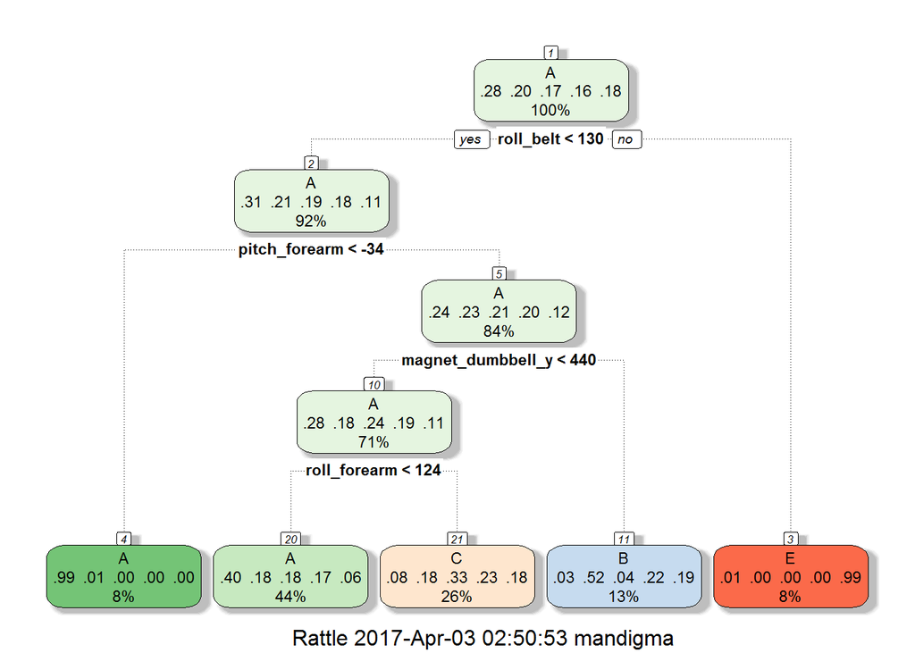

```r
fancyRpartPlot(model_fit$finalModel)
```

```r
prediction_tree <- predict(model_fit, data_test)
(confusionmatrix_tree <- confusionMatrix(data_test$classe, prediction_tree))
```

```
## Confusion Matrix and Statistics
##
##           Reference
## Prediction    A    B    C    D    E
##          A 1030   22   90    0    3
##          B  317  233  185    0    0
##          C  304   29  349    0    0
##          D  273  119  255    0    0
##          E   98   98  201    0  319
##
## Overall Statistics
##
##                Accuracy : 0.492
##                  95% CI : (0.4762, 0.5077)
##     No Information Rate : 0.5152
##     P-Value [Acc > NIR] : 0.9983
##
##                   Kappa : 0.3342
##  Mcnemar's Test P-Value : NA
##
## Statistics by Class:
##
##                      Class: A Class: B Class: C Class: D Class: E
## Sensitivity            0.5094  0.46507  0.32315       NA  0.99068
## Specificity            0.9396  0.85339  0.88295   0.8352  0.88981
## Pos Pred Value         0.8996  0.31701  0.51173       NA  0.44553
## Neg Pred Value         0.6432  0.91599  0.77459       NA  0.99907
## Prevalence             0.5152  0.12764  0.27516   0.0000  0.08204
## Detection Rate         0.2624  0.05936  0.08892   0.0000  0.08127
## Detection Prevalence   0.2917  0.18726  0.17376   0.1648  0.18242
## Balanced Accuracy      0.7245  0.65923  0.60305       NA  0.94025
```

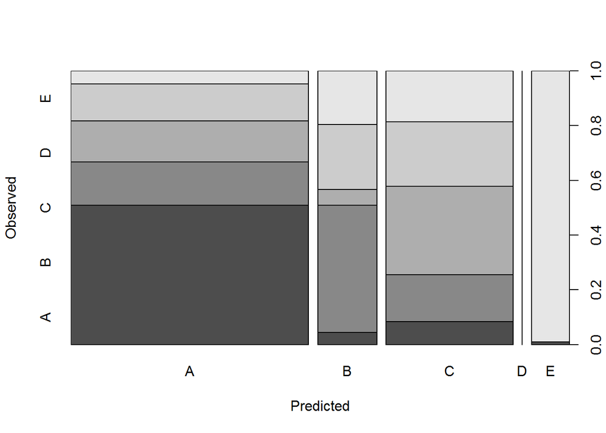

```r
plot(data.frame("Predicted"=predict(model_fit, data_test), "Observed"=data_test$classe))
```

## Random Forest

We will next try using the Random FOrest method if we can have a better outcome.

```r
fit_ranFor <- randomForest(classe ~. , data=data_train)
print(fit_ranFor, digits = 4)
```

```
##
## Call:
##  randomForest(formula = classe ~ ., data = data_train)
##                Type of random forest: classification
##                      Number of trees: 500
## No. of variables tried at each split: 7
##
##         OOB estimate of  error rate: 0.4%
## Confusion matrix:
##      A    B    C    D    E  class.error
## A 4433    2    0    0    0 0.0004509583
## B   11 3047    4    0    0 0.0048987590
## C    0   13 2726    1    0 0.0051094891
## D    0    0   21 2546    2 0.0089529000
## E    0    0    3    6 2882 0.0031131097
```

```r
predict_ranFor <- predict(fit_ranFor, data_test)
(conf_ranFor <- confusionMatrix(data_test$classe, predict_ranFor))
```

```
## Confusion Matrix and Statistics
##
##           Reference
## Prediction    A    B    C    D    E
##          A 1145    0    0    0    0
##          B    0  733    2    0    0
##          C    0    4  678    0    0
##          D    0    0    6  641    0
##          E    0    0    0    2  714
##
## Overall Statistics
##
##                Accuracy : 0.9964
##                  95% CI : (0.994, 0.998)
##     No Information Rate : 0.2917
##     P-Value [Acc > NIR] : < 2.2e-16
##
##                   Kappa : 0.9955
##  Mcnemar's Test P-Value : NA
##
## Statistics by Class:
##
##                      Class: A Class: B Class: C Class: D Class: E
## Sensitivity            1.0000   0.9946   0.9883   0.9969   1.0000
## Specificity            1.0000   0.9994   0.9988   0.9982   0.9994
## Pos Pred Value         1.0000   0.9973   0.9941   0.9907   0.9972
## Neg Pred Value         1.0000   0.9987   0.9975   0.9994   1.0000
## Prevalence             0.2917   0.1878   0.1748   0.1638   0.1819
## Detection Rate         0.2917   0.1868   0.1727   0.1633   0.1819
## Detection Prevalence   0.2917   0.1873   0.1738   0.1648   0.1824
## Balanced Accuracy      1.0000   0.9970   0.9936   0.9975   0.9997
```

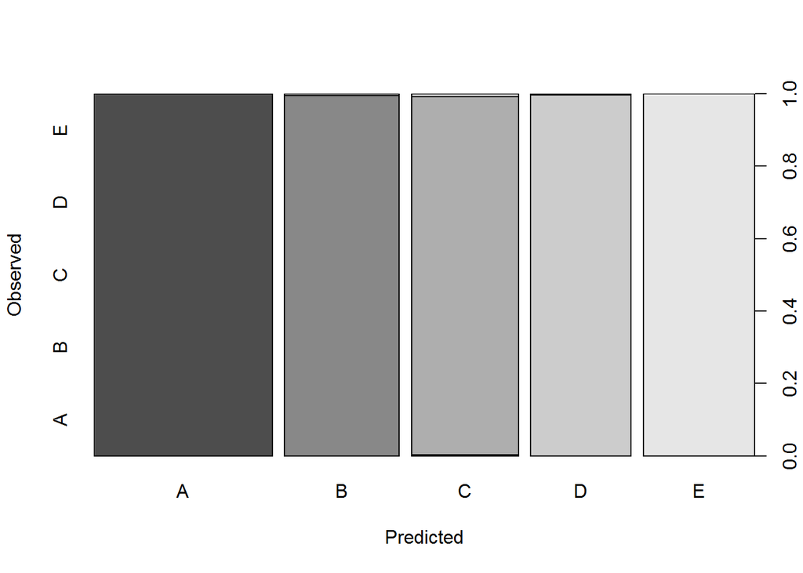

```r
plot(data.frame("Predicted"=predict(fit_ranFor, data_test), "Observed"=data_test$classe))
```

# Prediction on the testing data set

We will now predict the testing data for 1 to 20. These will be the answers to the quiz.

```r
prediction_final <- predict(fit_ranFor, testData, type = "class")
data.frame( problem_id=testcsv$problem_id, predicted=prediction_final)
```

```
##    problem_id predicted
## 1           1         B
## 2           2         A
## 3           3         B
## 4           4         A
## 5           5         A
## 6           6         E
## 7           7         D
## 8           8         B
## 9           9         A
## 10         10         A
## 11         11         B
## 12         12         C
## 13         13         B
## 14         14         A
## 15         15         E
## 16         16         E
## 17         17         A
## 18         18         B
## 19         19         B
## 20         20         B
```